# Experimento Aleatorio, Espacio Muestral Conteo

04/20/2020

## Definiciones

- La **Estadística** se ocupa de los métodos y procedimientos para recoger, clasificar, resumir, y analizar datos; datos que muestran variabilidad e incertidumbre misma que es la causa intrínseca de los mismos. También se ocupa de realizar inferencias a partir de ellos, con la finalidad de ayudar a la toma de decisiones y en su caso formular predicciones.
- **Historia de la Estadística:**
  - Su raíz: STATUS=cosas del estado.
  - Durante el siglo pasado, era consideradacomo la Ciencia del Estado.
  - Sus orígenes: El recuento.
  - Las civilizaciones antiguas recogían datos sobre población, producción agrícola y renta.

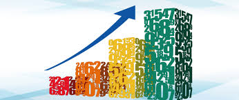

- La **Estadística** es la ciencia de la interpretación de datos y de la toma de decisiones en entornos de variabilidad e incertidumbre.

## Definiciones

- **Experimento Aletorio** Es aquel donde sus resultados dependen del Azar.

[figure not shown]

- Al análisis de los eventos gobernados por la incertidumbre se hace a través de la probabilidad, que es la base estadística.
- La probabilidad define qué tan posible es que ocurra un evento determinado.

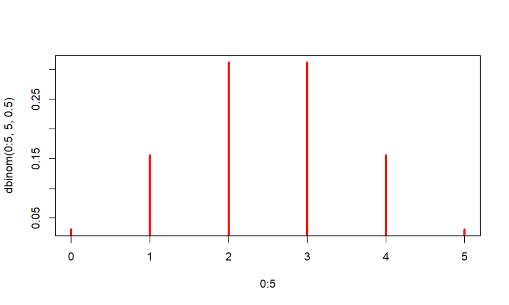

**Ejemplo** - Lanzamiento de un dado - Lanzamiento de una moneda - Extraer un boba numerada de un bolillero

## Definiciones

- El **“espacio muestral”** de un experimento está formado por todos los posibles resultados de un experimento aleatorio. Es decir, se compone de todos y cada uno de los sucesos elementales.

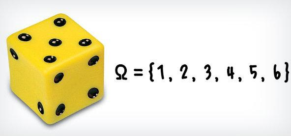

## Definiciones

- **Suceso** es un resultado posible cuando se realiza un experimento aleatorio sobre el que hay cierto interés.

**Ejemplo:** * Obtener un 6 al lanzar un dado: \[A=\{6\}\] * Obtener un número par al lanzar un dado: \[A=\{2,4,6\}\]

- Los sucesos son subconjuntos de de los elementos del espacio muestral: \(A \subset \Omega\)
- **Suceso elemental**: Es aquel suceso que está formado por un sólo elemento de los posibles que conforman el espacio muestral.
- **Suceso compuesto** Aquel suceso que está conformado por más de un suceso elemental